# DS152 Introduction to Data Science (2)

Assignment 6: Unsupervised Learning

Author

Prof. Niamh Cahill

## Instructions

Answer all questions for continuous assessment. Due: **4pm on Friday, 18th April 2025**.

## Exercise

1. Which of the following is not required for k-means clustering?
1. A distance metric
2. Initial number of clusters
3. Initial guess as to cluster centroids
4. All of the above are required.
2. In k-means, k stands for
1. Number of data points
2. Number of center points
3. Number of iterations to run the algorithm for
4. Number of variables
3. Which of the following can act as a possible termination condition for the k-means algorithm?
1. Fixing the number of clusters
2. When the assignment of observations to clusters does not change between iterations.
3. When each cluster has at least k data points
4. When the algorithm has been run for k iterations
4. For this analysis, we will work with the banknotes dataset to perform k-means clustering. First, we visualise the data by plotting Top vs Diagonal and colouring by Status (counterfeit, genuine) as shown below.

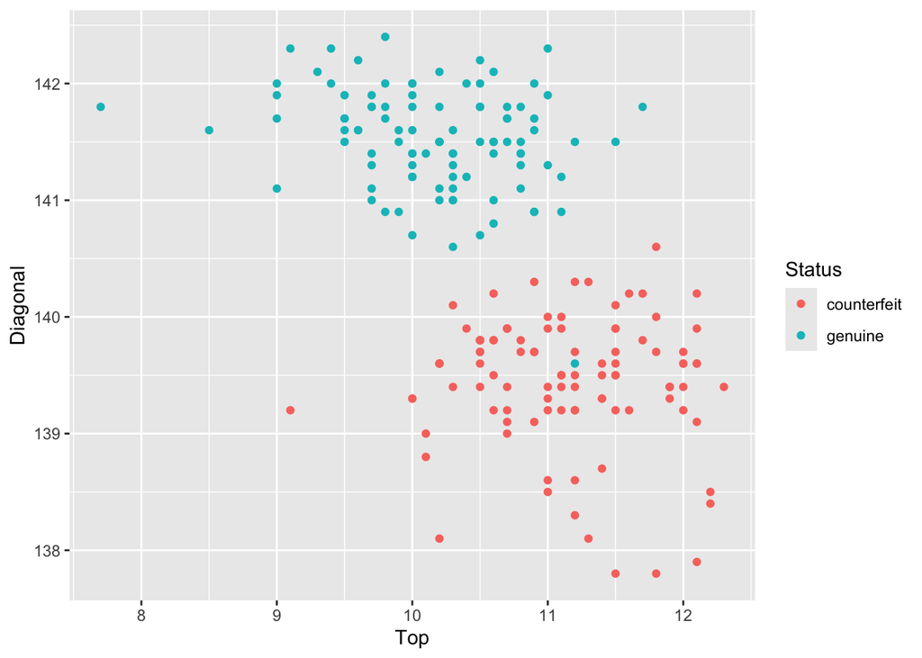

Replace [A], [B], [C], [D] and [E] in the code below to create this plot.

```r
ggplot(banknote, [A](x = [B], y = [C], colour = [D])) +
  [E]()
```

5. Now, let’s perform k-means clustering. We will ignore the fact that the banknotes are classified as genuine or counterfeit, and work only with the variables `Top` and `Diagonal` to see if the k-means algorithm with k = 2 will cluster the genuine notes into a group and the counterfeit notes into a group. Firstly, we will create a new dataset that contains only the `Top` and `Diagonal` from the banknote dataset. Then we will run the kmeans algorithm with 2 clusters on this data. Replace [A],[B] and [C] in the code such that this objective can be achieved.

```r
banknote2 <- banknote %>%
              [A](Top, Diagonal)

kmean_res <- [B](banknote2, centers = [C])
```

6. Next we want to visualise the results in the following way:

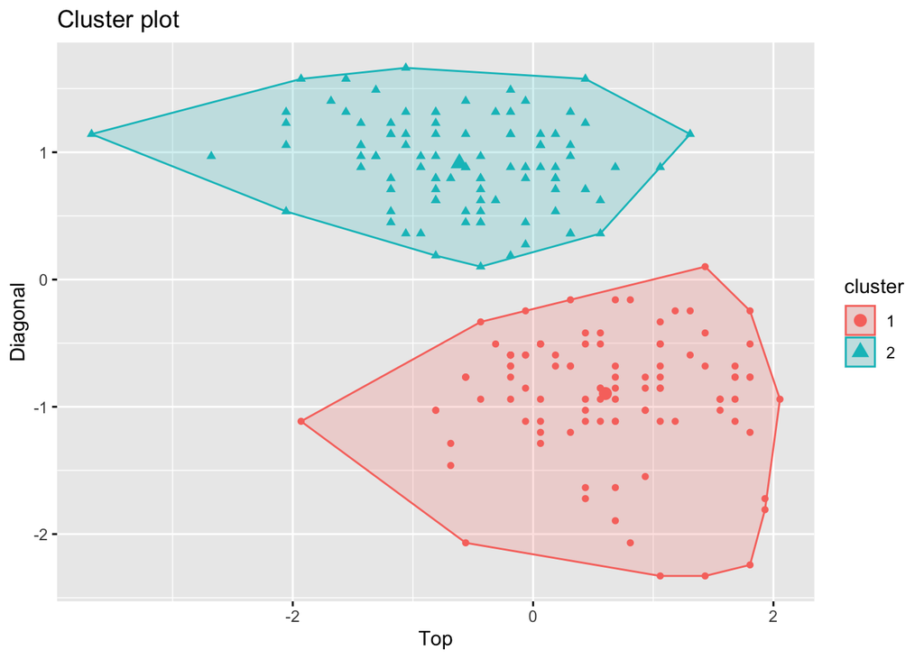

Replace [A], [B], [C] in the code below to create this plot.

```r
library(factoextra)
[A]([B] , data = banknote2, [C] = "point")
```

7. Based on comparing the plot in part 6 with the plot in part 4, did the k-means algorithm cluster all the genuine notes into the same cluster? Give a reason for your answer.